# Algoritmos de Regresión

## Regresión Lineal Simple

La Regresión Lineal Simple es un modelo de regresión en donde una función lineal representa la relación existente entre una variable dependiente y su respectiva variable independiente. Es decir, la ecuación que describe el modelo adopta la forma y=ax+b, en donde y es la variable dependiente, x es la variable independiente, y a y b son los coeficientes de la recta (pendiente y punto de corte, respectivamente) que, bajo algún criterio de minimización como el de mínimos cuadrados, ofrece el mejor ajuste a los datos de entrada.

Para este supuesto se trata de evaluar la linealidad de el salario de en función de los años de experiencia.

```python
# Importar las librerías
import numpy as np
import matplotlib.pyplot as plt
import pandas as pd
```

```python
# Importar el data set
dataset = pd.read_csv('Salary_Data.csv')
X = dataset.iloc[:, :-1].values
y = dataset.iloc[:, 1].values
print(dataset[:5])
```

```
   YearsExperience   Salary
0              1.1  39343.0
1              1.3  46205.0
2              1.5  37731.0
3              2.0  43525.0
4              2.2  39891.0
```

```python
# Dividir el data set en conjunto de entrenamiento y conjunto de testing
from sklearn.model_selection import train_test_split
X_train, X_test, y_train, y_test = train_test_split(X, y, test_size = 1/3, random_state = 0)
```

```python
# Crear modelo de Regresión Lineal Simple con el conjunto de entrenamiento
from sklearn.linear_model import LinearRegression
regression = LinearRegression()
regression.fit(X_train, y_train)
```

```
LinearRegression(copy_X=True, fit_intercept=True, n_jobs=None,
         normalize=False)
```

```python
# Predecir el conjunto de test
y_pred = regression.predict(X_test)
```

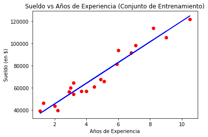

```python
# Visualizar los resultados de entrenamiento
plt.scatter(X_train, y_train, color = "red")
plt.plot(X_train, regression.predict(X_train), color = "blue")
plt.title("Sueldo vs Años de Experiencia (Conjunto de Entrenamiento)")
plt.xlabel("Años de Experiencia")
plt.ylabel("Sueldo (en $)")
plt.show()
```

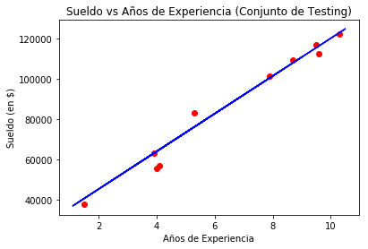

```python
# Visualizar los resultados de test
plt.scatter(X_test, y_test, color = "red")
plt.plot(X_train, regression.predict(X_train), color = "blue") #es la misma recta con datos de X_train como X_test
plt.title("Sueldo vs Años de Experiencia (Conjunto de Testing)")
plt.xlabel("Años de Experiencia")
plt.ylabel("Sueldo (en $)")
plt.show()
```

## Regresión Lineal Múltiple

Aplicación de la regresión lineal múltiple para evaluar que variables son más relevantes a la hora de invertir en una startup.

```python
# Importar las librerías
import numpy as np
import matplotlib.pyplot as plt
import pandas as pd
```

```python
# Importar el data set
dataset = pd.read_csv('50_Startups.csv')
X = dataset.iloc[:, :-1].values
y = dataset.iloc[:, 4].values
print(dataset[:5])
```

```
   R&D Spend  Administration  Marketing Spend       State     Profit
0  165349.20       136897.80        471784.10    New York  192261.83
1  162597.70       151377.59        443898.53  California  191792.06
2  153441.51       101145.55        407934.54     Florida  191050.39
3  144372.41       118671.85        383199.62    New York  182901.99
4  142107.34        91391.77        366168.42     Florida  166187.94
```

```python
# Codificar datos categóricos
from sklearn.preprocessing import LabelEncoder, OneHotEncoder
labelencoder_X = LabelEncoder()
X[:, 3] = labelencoder_X.fit_transform(X[:, 3])
onehotencoder = OneHotEncoder(categorical_features=[3])
X = onehotencoder.fit_transform(X).toarray()
```

```python
# Evitar la trampa de las variables ficticias
X = X[:, 1:]
```

```python
# Dividir el data set en conjunto de entrenamiento y conjunto de testing
from sklearn.model_selection import train_test_split
X_train, X_test, y_train, y_test = train_test_split(X, y, test_size = 0.2, random_state = 0)
```

```python
# Ajustar el modelo de Regresión lineal múltiple con el conjunto de entrenamiento
from sklearn.linear_model import LinearRegression
regression = LinearRegression()
regression.fit(X_train, y_train)
```

```
LinearRegression(copy_X=True, fit_intercept=True, n_jobs=None,
         normalize=False)
```

```python
# Predicción de los resultados en el conjunto de testing
y_pred = regression.predict(X_test)
```

```python
# Construir el modelo óptimo de RLM utilizando la Eliminación hacia atrás
import statsmodels.formula.api as sm
X = np.append(arr = np.ones((50,1)).astype(int), values = X, axis = 1)
SL = 0.05
```

```python
X_opt = X[:, [0, 1, 2, 3, 4, 5]]
regression_OLS = sm.OLS(endog = y, exog = X_opt).fit()
regression_OLS.summary()
```

OLS Regression Results

| Dep. Variable: | y | R-squared: | 0.951 |
| --- | --- | --- | --- |
| Model: | OLS | Adj. R-squared: | 0.945 |
| Method: | Least Squares | F-statistic: | 169.9 |
| Date: | Thu, 16 May 2019 | Prob (F-statistic): | 1.34e-27 |
| Time: | 13:16:18 | Log-Likelihood: | -525.38 |
| No. Observations: | 50 | AIC: | 1063. |
| Df Residuals: | 44 | BIC: | 1074. |
| Df Model: | 5 |  |  |
| Covariance Type: | nonrobust |  |  |

|  | coef | std err | t | P>\|t\| | [0.025 | 0.975] |
| --- | --- | --- | --- | --- | --- | --- |
| const | 5.013e+04 | 6884.820 | 7.281 | 0.000 | 3.62e+04 | 6.4e+04 |
| x1 | 198.7888 | 3371.007 | 0.059 | 0.953 | -6595.030 | 6992.607 |
| x2 | -41.8870 | 3256.039 | -0.013 | 0.990 | -6604.003 | 6520.229 |
| x3 | 0.8060 | 0.046 | 17.369 | 0.000 | 0.712 | 0.900 |
| x4 | -0.0270 | 0.052 | -0.517 | 0.608 | -0.132 | 0.078 |
| x5 | 0.0270 | 0.017 | 1.574 | 0.123 | -0.008 | 0.062 |

| Omnibus: | 14.782 | Durbin-Watson: | 1.283 |
| --- | --- | --- | --- |
| Prob(Omnibus): | 0.001 | Jarque-Bera (JB): | 21.266 |
| Skew: | -0.948 | Prob(JB): | 2.41e-05 |
| Kurtosis: | 5.572 | Cond. No. | 1.45e+06 |

Warnings:  
[1] Standard Errors assume that the covariance matrix of the errors is correctly specified.  
[2] The condition number is large, 1.45e+06. This might indicate that there are  
strong multicollinearity or other numerical problems.

```python
X_opt = X[:, [0, 1, 3, 4, 5]]
regression_OLS = sm.OLS(endog = y, exog = X_opt).fit()
regression_OLS.summary()
```

OLS Regression Results

| Dep. Variable: | y | R-squared: | 0.951 |
| --- | --- | --- | --- |
| Model: | OLS | Adj. R-squared: | 0.946 |
| Method: | Least Squares | F-statistic: | 217.2 |
| Date: | Thu, 16 May 2019 | Prob (F-statistic): | 8.49e-29 |
| Time: | 13:16:18 | Log-Likelihood: | -525.38 |
| No. Observations: | 50 | AIC: | 1061. |
| Df Residuals: | 45 | BIC: | 1070. |
| Df Model: | 4 |  |  |
| Covariance Type: | nonrobust |  |  |

|  | coef | std err | t | P>\|t\| | [0.025 | 0.975] |
| --- | --- | --- | --- | --- | --- | --- |
| const | 5.011e+04 | 6647.870 | 7.537 | 0.000 | 3.67e+04 | 6.35e+04 |
| x1 | 220.1585 | 2900.536 | 0.076 | 0.940 | -5621.821 | 6062.138 |
| x2 | 0.8060 | 0.046 | 17.606 | 0.000 | 0.714 | 0.898 |
| x3 | -0.0270 | 0.052 | -0.523 | 0.604 | -0.131 | 0.077 |
| x4 | 0.0270 | 0.017 | 1.592 | 0.118 | -0.007 | 0.061 |

| Omnibus: | 14.758 | Durbin-Watson: | 1.282 |
| --- | --- | --- | --- |
| Prob(Omnibus): | 0.001 | Jarque-Bera (JB): | 21.172 |
| Skew: | -0.948 | Prob(JB): | 2.53e-05 |
| Kurtosis: | 5.563 | Cond. No. | 1.40e+06 |

Warnings:  
[1] Standard Errors assume that the covariance matrix of the errors is correctly specified.  
[2] The condition number is large, 1.4e+06. This might indicate that there are  
strong multicollinearity or other numerical problems.

```python
X_opt = X[:, [0, 3, 4, 5]]
regression_OLS = sm.OLS(endog = y, exog = X_opt).fit()
regression_OLS.summary()
```

OLS Regression Results

| Dep. Variable: | y | R-squared: | 0.951 |
| --- | --- | --- | --- |
| Model: | OLS | Adj. R-squared: | 0.948 |
| Method: | Least Squares | F-statistic: | 296.0 |
| Date: | Thu, 16 May 2019 | Prob (F-statistic): | 4.53e-30 |
| Time: | 13:16:18 | Log-Likelihood: | -525.39 |
| No. Observations: | 50 | AIC: | 1059. |
| Df Residuals: | 46 | BIC: | 1066. |
| Df Model: | 3 |  |  |
| Covariance Type: | nonrobust |  |  |

|  | coef | std err | t | P>\|t\| | [0.025 | 0.975] |
| --- | --- | --- | --- | --- | --- | --- |
| const | 5.012e+04 | 6572.353 | 7.626 | 0.000 | 3.69e+04 | 6.34e+04 |
| x1 | 0.8057 | 0.045 | 17.846 | 0.000 | 0.715 | 0.897 |
| x2 | -0.0268 | 0.051 | -0.526 | 0.602 | -0.130 | 0.076 |
| x3 | 0.0272 | 0.016 | 1.655 | 0.105 | -0.006 | 0.060 |

| Omnibus: | 14.838 | Durbin-Watson: | 1.282 |
| --- | --- | --- | --- |
| Prob(Omnibus): | 0.001 | Jarque-Bera (JB): | 21.442 |
| Skew: | -0.949 | Prob(JB): | 2.21e-05 |
| Kurtosis: | 5.586 | Cond. No. | 1.40e+06 |

Warnings:  
[1] Standard Errors assume that the covariance matrix of the errors is correctly specified.  
[2] The condition number is large, 1.4e+06. This might indicate that there are  
strong multicollinearity or other numerical problems.

```python
X_opt = X[:, [0, 3, 5]]
regression_OLS = sm.OLS(endog = y, exog = X_opt).fit()
regression_OLS.summary()
```

OLS Regression Results

| Dep. Variable: | y | R-squared: | 0.950 |
| --- | --- | --- | --- |
| Model: | OLS | Adj. R-squared: | 0.948 |
| Method: | Least Squares | F-statistic: | 450.8 |
| Date: | Thu, 16 May 2019 | Prob (F-statistic): | 2.16e-31 |
| Time: | 13:16:18 | Log-Likelihood: | -525.54 |
| No. Observations: | 50 | AIC: | 1057. |
| Df Residuals: | 47 | BIC: | 1063. |
| Df Model: | 2 |  |  |
| Covariance Type: | nonrobust |  |  |

|  | coef | std err | t | P>\|t\| | [0.025 | 0.975] |
| --- | --- | --- | --- | --- | --- | --- |
| const | 4.698e+04 | 2689.933 | 17.464 | 0.000 | 4.16e+04 | 5.24e+04 |
| x1 | 0.7966 | 0.041 | 19.266 | 0.000 | 0.713 | 0.880 |
| x2 | 0.0299 | 0.016 | 1.927 | 0.060 | -0.001 | 0.061 |

| Omnibus: | 14.677 | Durbin-Watson: | 1.257 |
| --- | --- | --- | --- |
| Prob(Omnibus): | 0.001 | Jarque-Bera (JB): | 21.161 |
| Skew: | -0.939 | Prob(JB): | 2.54e-05 |
| Kurtosis: | 5.575 | Cond. No. | 5.32e+05 |

Warnings:  
[1] Standard Errors assume that the covariance matrix of the errors is correctly specified.  
[2] The condition number is large, 5.32e+05. This might indicate that there are  
strong multicollinearity or other numerical problems.

```python
X_opt = X[:, [0, 3]]
regression_OLS = sm.OLS(endog = y, exog = X_opt).fit()
regression_OLS.summary()
```

OLS Regression Results

| Dep. Variable: | y | R-squared: | 0.947 |
| --- | --- | --- | --- |
| Model: | OLS | Adj. R-squared: | 0.945 |
| Method: | Least Squares | F-statistic: | 849.8 |
| Date: | Thu, 16 May 2019 | Prob (F-statistic): | 3.50e-32 |
| Time: | 13:16:18 | Log-Likelihood: | -527.44 |
| No. Observations: | 50 | AIC: | 1059. |
| Df Residuals: | 48 | BIC: | 1063. |
| Df Model: | 1 |  |  |
| Covariance Type: | nonrobust |  |  |

|  | coef | std err | t | P>\|t\| | [0.025 | 0.975] |
| --- | --- | --- | --- | --- | --- | --- |
| const | 4.903e+04 | 2537.897 | 19.320 | 0.000 | 4.39e+04 | 5.41e+04 |
| x1 | 0.8543 | 0.029 | 29.151 | 0.000 | 0.795 | 0.913 |

| Omnibus: | 13.727 | Durbin-Watson: | 1.116 |
| --- | --- | --- | --- |
| Prob(Omnibus): | 0.001 | Jarque-Bera (JB): | 18.536 |
| Skew: | -0.911 | Prob(JB): | 9.44e-05 |
| Kurtosis: | 5.361 | Cond. No. | 1.65e+05 |

Warnings:  
[1] Standard Errors assume that the covariance matrix of the errors is correctly specified.  
[2] The condition number is large, 1.65e+05. This might indicate that there are  
strong multicollinearity or other numerical problems.